# GIS in R final exam: Your weird new boss counts caterpillars

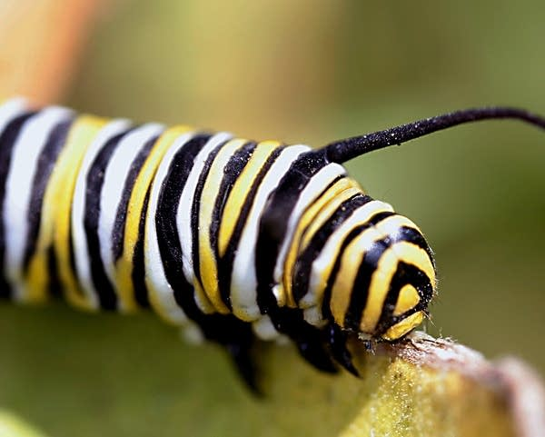

You have been contracted as a GIS technician for the nonprofit organization “Street Trees for Wildlife”! The organization is preparing to sample caterpillars on street trees in Washington, DC.

Your goal is to provide the GIS support needed to select and classify sampling locations within 1 km of Metro stations in Washington, DC.

This project will evaluate a number of GIS in R skills, including (*but not limited to!*) your ability to:

- Read and preprocess tabular, vector, and raster data
- Subset, mutate, summarize, reshape, and visualize data
- Use iteration to apply the same spatial workflow to several files
- Conduct spatial and non-spatial joins
- Choose and apply geometric operations
- Classify vector and raster data
- Align raster grids and combine raster and vector data
- Generate static and interactive maps

### Getting started

Download final_exam_data.zip, unzip it, and place the `final_exam_data` folder in `data/raw`.

Download final_exam.R and place it in your `scripts` folder. Write your answer to each memo below its header in this script file.

### Grading

**Total points available**: 30

You will hand in a single R script file for this assignment. This file must include all of the code used to answer each memo.

**Each memo is worth 3 points** (10% of the exam). You will be graded on your **10 highest-scoring memos** (feel free to skip some memos if you are confident in your answers!).

Points may be deducted from each memo’s total:

- [1.0 points per violation] Globally assign only the objects specified in the memo
- [1.0] Use only functions that we have used in this course **or** *any* function from the *sf*, *tidyterra*, *tidyverse*, and *tmap* packages
- [0.50] Ensure that the class of your response is consistent with the wording of the memo (e.g., if you are asked to return a “value” or “vector”, the result should not be a data frame)
- [0.30] Code parsimony
- [0.30] Use column names, not numeric indices, when subsetting columns

*Note: The maximum deduction is the total point value of a memo.*

**An additional 10% of a memo’s original point value will be awarded when the response follows all applicable rules in the [Course style guide](https://evansbrians.github.io/gis_2026/resources/course_style_guide/). Style extra credit is assessed separately for each memo; a response with one or more style violations receives no style extra credit for that memo.**

You may use any function that we have used in this course **or** *any* function from the *sf*, *tidyterra*, *tmap*, and *tidyverse* packages. Click the blue button below to view the functions that **I used** to complete this exam. Although you are *not* required to use the same functions as I did, you might find this list helpful!

**Important!** Primitive functions and functions in the *base* package are loaded by default when you start an R session. Functions in *dplyr*, *forcats*, *ggplot2*, *lubridate*, *purrr*, *readr*, *stringr*, *tibble*, and *tidyr* are loaded with `library(tidyverse)`. Although the *magrittr* package is not part of the core tidyverse, `%>%` is imported by *dplyr*.

The table identifies the lesson in which each function was first used so that you can return to it.

| Package | Function | First lesson used | Definition |
| --- | --- | --- | --- |
| .Primitive | ! | 1.3_objects | Prefix logical operator (not) |
| .Primitive | (...) | -- | Group an expression or supply a function call's arguments. |
| .Primitive | * | 2.2_mutation | Infix arithmetic operator (multiply) |
| .Primitive | + | 0.1_intro_to_r_and_rstudio | Infix arithmetic operator (addition) |
| .Primitive | / | 0.4_objects | Infix arithmetic operator (divide) |
| .Primitive | : | 0.3_values | Infix operator that generates a regular sequence of adjacent values |
| .Primitive | :: | 1.2_getting_started | Infix operator that can be used to access a package environment without attaching the whole package environment to your current session |
| .Primitive | <- | 0.2_environment_and_functions | Infix operator that assigns an object on the right-hand-side (RHS) to a name on the left-hand-side (LHS) -- this should be used for global assignments! |
| .Primitive | = | 0.2_environment_and_functions | Infix operator that assigns an object on the right-hand-side (RHS) to a name on the left-hand-side (LHS) -- this should not be used for global assignments! |
| .Primitive | < | 0.3_values | Infix relational operator (less than) |
| .Primitive | == | 0.3_values | Infix relational operator (is equal to) |
| .Primitive | > | 0.3_values | Infix relational operator (greater than) |
| .Primitive | >= | 2.1_subsetting_and_extraction | Infix relational operator (greater than or equal to) |
| .Primitive | as.numeric | 0.3_values | Transform an atomic vector to a double numeric vector (i.e., decimal numbers) |
| .Primitive | c | 0.2_environment_and_functions | Combine values to form an atomic vector |
| .Primitive | is.na | 2.1_subsetting_and_extraction | A logical test of whether a value in a vector is [NA] |
| .Primitive | lengths | 5.4_categorizing_spatial_data | Return the length of every element of a list |
| .Primitive | list | 0.4_objects | Combine multiple objects of any type into a single, recursive, data object |
| .Primitive | max | 1.4_importing_exploring_exporting | Return the highest value in a numeric vector (integer or double) as a one-value numeric or integer vector (depending on input) |
| .Primitive | sum | 0.3_values | Calculate the sum of the values in a numeric vector. |
| .Primitive | {...} | 4.4_iteration | Operator that passes the last operation in `{...}` to the global environment |
| .Primitive | ~ | 1.3_objects | The formula operator separates the left- and right-hand sides (LHS and RHS) in a formula. |
| base | %in% | 0.3_values | Infix relational operator that tests whether the values on the left-hand-side (LHS) are found within the vector on the right-hand-side (RHS) |
| base | as.data.frame | 6.2_categorical_rasters | Convert an object to a data frame. |
| base | as.matrix | 3.3_constructing_and_converting_shapefiles | Convert a data frame to a matrix |
| base | levels | 1.4_importing_exploring_exporting | Generate a character vector of factor levels in a factor variable |
| base | library | 0.2_environment_and_functions | Attach the package environment for a given package to the current R session |
| base | list2env | 2.1_subsetting_and_extraction | Assign the items in a list to a specified environment |
| base | set.seed | 5.1_focus_on_points | Fix the random number generator so that a random operation returns the same result each time it is run. |
| dplyr | arrange | 1.4_importing_exploring_exporting | Sort the rows of a data frame by the values in a variable or variables |

[output cut: 80 more lines]

## Memo 1

Welcome to the team GIS Guru!

Please start by saving your R script as `final_exam_[your last name]_[your first name].R`, using snake case.

Sincerely,

Your new boss!

## Memo 2

Hello GIS Guru,

We are super into the *sf*, *tidyterra*, *tmap*, and *tidyverse* packages around here. We especially like the tidyverse. I have a life-sized poster of Hadley in my office. Please attach those packages, in that order, before proceeding!

Cheers,

Your new boss!

P.S. I am also a big fan of interactive maps, so please set your *tmap* mode to “view”!

## Memo 3

Dear GIS Guru,

Let’s get started by preparing the raster data. Two of the files are in `data/raw/final_exam_data`: `nlcd_key.csv` and `classified_lc.tif`.

As you may have suspected, `nlcd_key.csv` is the key to `classified_lc.tif`. It includes the following fields:

- `id`: A unique identifier for each land cover class
- `name`: The name of each land cover class
- `color_value`: Colors typically used to visualize land cover classes
- `description`: A detailed description of each class

`classified_lc.tif` is a GeoTIFF obtained from the [Multi-Resolution Land Characteristics Consortium (MRLC)](https://www.mrlc.gov/data). This categorical raster describes the dominant land cover class within each approximately 30 × 30 m cell in the District of Columbia. Its CRS is WGS 84 / UTM zone 18N (EPSG 32618).

Prepare the following objects:

- `nlcd_key`: Retain `id` and `name` from `nlcd_key.csv`, rename `name` to `land_cover`, and globally assign the result.
- `lc`: Read `classified_lc.tif`, globally assign the result, and use `nlcd_key` as its category table.
- `dem`: Prepare `data/raw/final_exam_data/dem_dc_10m.tif` as a layer named `elevation` with the CRS and grid of `lc`. Calculate the mean elevation of the source cells that contribute to each output cell.

Globally assign only the names requested above.

Warm regards,

Your “meta” boss

## Memo 4

Bonjour GIS Guru!

I have a number of spatial vector files that I would like you to use for this project. Each file was obtained from [Open Data DC](https://opendata.dc.gov/). The files are in `data/raw/final_exam_data` and use the unprojected coordinate reference system WGS 84 (EPSG 4326):

- `Metro_Stations_in_DC.geojson`: Point features representing Metro stations in Washington, DC
- `National_Parks_DC.geojson`: Multipolygon features representing land managed by the US National Park Service in Washington, DC
- `streets_simple.geojson`: Line features representing a simplified version of the roads in Washington, DC
- `Wards_from_2022.geojson`: Polygon features representing local voting areas in Washington, DC

Use iteration to read and preprocess all four files. Each resulting object should retain the geometry and a single field named `name`, derived from `NAME`, and should use EPSG 32618. Suppress the printing of each file’s metadata.

Globally assign the four objects to `metro_stops`, `national_parks`, `streets`, and `wards`.

Au revoir,

Your sophisticated boss

## Memo 5

Hiya GIS Guru,

I’ve got a big processing step for you. The file `data/raw/final_exam_data/Urban_Forestry_Street_Trees.csv` is a pretty gigantic tabular dataset that I downloaded from [Open Data DC](https://opendata.dc.gov/). Each record represents a street tree in the District of Columbia. There are a lot of columns in the dataset, but we are only interested in:

- `GENUS_NAME`: The genus of the street trees
- `DBH`: The diameter of the street tree trunks, in inches
- `X`: The longitudinal coordinates of the street trees, recorded in EPSG 4326
- `Y`: The latitudinal coordinates of the street trees, recorded in EPSG 4326

Read and preprocess the file, then globally assign the result to `trees`. The finished object should:

- Use the four fields above, renamed `genus`, `dbh`, `longitude`, and `latitude`
- Exclude records with a missing value or a genus recorded as “No” or “Other”
- Include only trees with a diameter greater than 30 centimeters, without retaining `dbh`
- Classify *Quercus* as “oak”, *Acer* as “maple”, and every other genus as “other”
- Be a simple features POINT object in EPSG 32618 that contains only trees within `wards`

Ta ta,

Your oddly data-aware boss

## Memo 6

Top of the morning to you GIS Guru!

Our team is primarily interested in oaks and maples, but the other trees still count! Please provide two results:

- A tibble data frame with one row for each ward, fields giving the numbers of oaks and maples, and a field named `total` giving the number of trees across all classes. Do not include the count of the “other” class as a separate field, and sort the result by ward.
- A ggplot bar plot of the number of trees in each ward, divided into facets by tree class. Give the axes informative labels.

Slán leat,

Your gaffer

## Memo 7

How dost thou fare GIS Guru?

The “wards” (District of Columbia voting areas) are keenly interested in our study! They want to know whether the apparent differences in tree abundance simply reflect the size of each ward. Generate a ggplot map of the wards in which fill color represents the number of trees per square kilometer. Include an informative legend title.

Fare-thee-well,

Your old-fashioned boss

## Memo 8

G’day GIS Guru,

The “battle of the wards” is heating up! They have now moved on from trees to parkland. Return a tibble data frame with one row for each ward and a field named `parkland_ha` giving the area of National Park Service land within it, in hectares. Sort the result by ward. Where park features overlap, count the shared area only once.

Hooroo,

Your ggplotin’ boss

## Memo 9

Howdy GIS Guru,

So far, so good pardner! Unfortunately, we have not gotten permission to sample on land managed by the National Park Service! Please:

- Return a tibble data frame giving the number of trees on National Park Service land and on other land. Classify the groups as “National Park Service” and “other”.
- Retain the trees that do not fall within *any* National Park Service feature and globally assign the result to `trees_no_nps`. *Hint: Unless you like waiting and/or overwhelming your system’s memory, avoid using `st_difference()` for this operation!*
- Provide an interactive map of `trees_no_nps` in which fill color represents tree class and nearby points are clustered.

Adios,

Your rootin’ tootin’ boss

## Memo 10

Buenos dias GIS Guru,

Our team is interested in the number of caterpillars on street trees. Previous studies have found that caterpillar abundance tends to be higher on trees close to forests, so we will exclude nearby trees from our sampling locations.

First, merge the classes of `lc` into “water” (11), “developed” (21 through 24), “forest” (41 through 43), and “other” (all remaining classes). Code the merged classes 1 through 4, respectively. Attach a category table whose label field is named `general_class`, and globally assign the raster to `general_lc`.

From that raster, prepare the following results:

- `forest`: A globally assigned raster in which forest cells have the value 1 and all other cells are NA.
- `forest_distance`: A globally assigned raster giving the distance in meters to the nearest forest cell. Name its layer `distance_m`, and retain values only within `wards`.
- A ggplot map of `forest_distance` with an informative legend title.
- `trees_no_forests`: A globally assigned simple features object containing the trees in `trees_no_nps` that are more than 100 meters from the nearest forest cell. Do not retain the extracted distance as a field.

Finally, set the seed to 2026 and use a random sample of 1,000 non-NA cells from `forest_distance` to estimate the median distance to forest across the wards.

Pura vida,

Your cartographic boss

## Memo 11

How ya doin’ GIS Guru?

We have been talking and we are all wicked impressed with the job you have been doing so far. Well, all of us except Chad, who is a bit of a tool. Chad said, “… yeah, but can they identify forest patches?” Now is a great time to show Chad-the-water-cooler-weirdo how it is done.

Identify the patches in `forest`, treating cells that touch at a corner as connected, and globally assign the result to `forest_patches`. Then return a tibble data frame with fields giving the number of patches, the area of the largest patch in hectares, and the number of patches that are at least 10 hectares.

Later,

Your awesome boss

## Memo 12

Salutations GIS Guru!

Before we start defining our sampling locations, we need to describe their terrain and forest context. We do not want our technicians walking down any steep streets or dark alleys.

- Calculate slope from `dem`, in degrees, and globally assign the result to `slope`.
- Return the mean slope of each class in `general_lc`.
- Generate a raster in which the value of each cell is the proportion of forest cells within its centered 7 × 7 window. Name its layer `forest_cover` and globally assign the raster to `forest_cover`.

Nanu Nanu,

Your suspicious boss

## Memo 13

Greetings GIS Guru!

Our technicians will sample caterpillars where named streets turn or intersect. They need at least five trees at a location, and we would rather not send them onto steep terrain. Here is our path forward:

- Generate `tree_counts`, a globally assigned raster on the grid of `lc` that contains the number of trees in `trees_no_forests`. Cells with no trees should have the value 0. Aggregate the raster by a factor of two using the sum, name its layer `trees`, and mask it to `wards`.
- Generate `street_points`, a globally assigned simple features object containing the distinct vertices of named streets. Do not retain the street name.
- Generate `sampling_points` by adding the number of trees, slope, and forest cover at each candidate point. Retain points with at least five trees and a slope of less than 10 degrees, then globally assign the result.

Live long and prosper,

Your nerdy boss

## Memo 14

Aloha GIS Guru,

We are almost ready to send out our field sampling team! Summers are hot in the District of Columbia, and we do not want our teams to have to walk too far during sampling. They will take the Metro to one of the following stations:

- Congress Heights
- Eastern Market
- Fort Totten
- Minnesota Ave
- Tenleytown-AU
- Woodley Park-Zoo Adams Morgan

Globally assign the sampling points near these stations to `sampling_metro`. The result should:

- Contain only points within 1 km of a listed station and retain the station name
- Include fields giving the numbers of oaks and maples from `trees_no_forests` within 30 meters of each point
- Include a field named `class` that combines “oak” or “no oak” with “maple” or “no maple”, separated by a comma and a space
- Include the two points with the most trees for each combination of Metro station and class, ignoring ties

Help our field technicians find the selected points by generating an interactive map on an Esri.WorldImagery basemap in which fill color represents `class`.

Mahalo,

Your super mellow boss

## Extra credit 1

The Eastern Market team has decided that walking in a straight line between sampling points is a perfectly reasonable plan. Return the length, in kilometers, of a path that begins at the Eastern Market Metro station and connects its sampling points in order of their distance from the station.

Your questionably practical boss

## Extra credit 2

Chad is back. This time, he wants to know where oaks are concentrated across the District.

Generate a raster of 100 × 100 m cells covering `wards` in which each cell contains the number of oaks in `trees`, including zeros where no oaks occur, and globally assign it to `oak_counts`. Use that raster to generate a kernel density surface of oaks per square kilometer with a Gaussian kernel and a bandwidth of 300 meters, then globally assign it to `oak_density`.

Provide a ggplot map of `oak_density` and return the name of the ward that contains its peak.

Your still-not-Chad boss